# Exploratory Report of Juvenile Hare Statistics

By: Grace Kumaishi

11/15/2020

## Introduction

This report explores physical data collected from trapped snowshoe hares (*Lepus americanus*) in the Bonanza Creek Experimental Forest between 1999 and 2012. The Bonanza Creek Experimental Forest is located in Tanana Valley, Alaska, and consists of numerous habitats that vary in density of cover (Feierabend and Kielland 2014). This report focuses on three sites of interest: Bonanza Riparian (a flood zone consisting of deciduous trees), Bonanza Mature (a mature site consisting of both deciduous trees and black spruce, *Picea mariana*), and Bonanza Black Spruce (a site used for live-trapping located in a mature black spruce stand) (Kielland et al. 2017). The analyses included here focus specifically on the recorded weight of juvenile hares trapped over the course of the study. In addition to exploratory visualizations of weight comparisons between sites and sex, we explore the relationship between juvenile weight and hind foot length.

## Data and analyses

Snowshoe hare measurements were collected and provided by Dr. Knut Kielland and collegues at the Bonanza Creek Long-Term Ecological Research (LTER) site located in Tanana Valley, Alaska. The data contain observations of adult and juvenile snowshoe hares trapped between 1999 and 2012. In addition to exploratory data visualization, weight measurements of juvenile male and female snowshoe hares are compared using two-sample t-tests (significance level ($\alpha$) of 0.05), while differences between sexes are described with Cohen’s *d* effect size. The relationship between juvenile hare weight and hind foot length is explored using a simple linear regression. Analyses were performed in R version 4.0.2 using RStudio version 1.3.1093.

## Exploratory findings

### 1) Annual juvenile hare trap counts

The maximum number of juvenile hares trapped during this study occurred in the first two years (1999 and 2000) with 126 and 67 individuals trapped, respectively. The following years fluctuate between zero (this occurred during years in which the age of hares was not specified in the data) and just under 50, which corroborates the authors’ statement that hare populations fluctuate over 8 to 11 years (Kielland et al. 2017). On average, 31.5 juvenile hares were captured per year, with a median value of 18.5. In order to standardize the juvenile hare population in future analyses, trap counts could be divided by time or trapping effort.

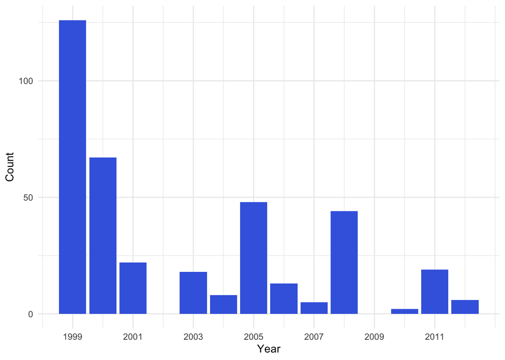

**Figure 1:** Number of juvenile hares trapped between 1999 and 2012 in the Bonanza Creek Experimental Forest, Tanana Valley, Alaska. Data: Kielland et al. (2017).

### 2) Visualize juvenile hare weights

To begin visualizing juvenile hare weights, a density plot including both sex and site was created (Figure 2). This plot allows us to visualize the spread of weights for male, female and unknown juvenile hares between each of the three sites. The density plot shows female weight peaking earlier than male weight in the Bonanza Mature and Bonanza Riparian sites, indicating that females may be smaller on average here. These trends are explored further in Figures 3 and 4, which allow us to examine the relationship between weight, sex, and site individually. When comparing weight and sex alone, male hares are heavier on average than female hares (with mean weights of 945.86 g and 855.39 g respectively). Over the three different sites, juvenile hares trapped at Bonanza Black Spruce weighed the most on average (1036.17 g), while the weights of juvenile hares captured at Bonanza Mature and Bonanza Riparian were relatively similar, with averages of 878.05 g and 862.59 g, respectively. Distributions of weight for both sex and site are relatively symmetric and lack notable outliers.

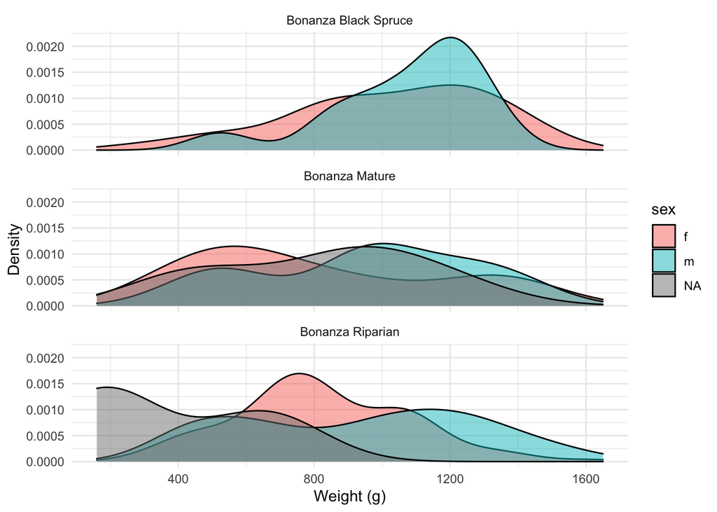

**Figure 2:** Density plots comparing weight in grams between sexes of juvenile snowshoe hares trapped at three different sites: Bonanza Black Spruce, Bonanza Mature, and Bonanza Riparian in the Bonanza Creek Experimental Forest, Tanana Valley, Alaska. Data: Kielland et al. (2017).

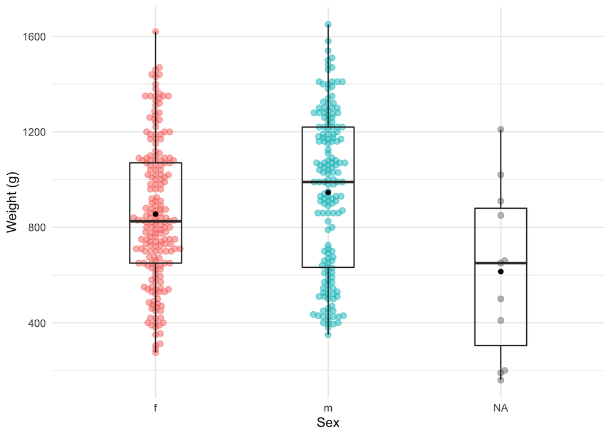

**Figure 3:** Weight observations (g) for juvenile snowshoe hares separated by sex (female, male, and NA). Pink (female), blue (male), and gray (sex not recorded) points indicate individual observations for weight (grams) of juvenile hares that were trapped between 1999 and 2012. Box endpoints indicate the 25<sup>th</sup> and 75<sup>th</sup> percentile values. The median value is indicated by a black line and the mean value is indicated by a black dot within the boxplot. Data: Kielland et al. (2017).

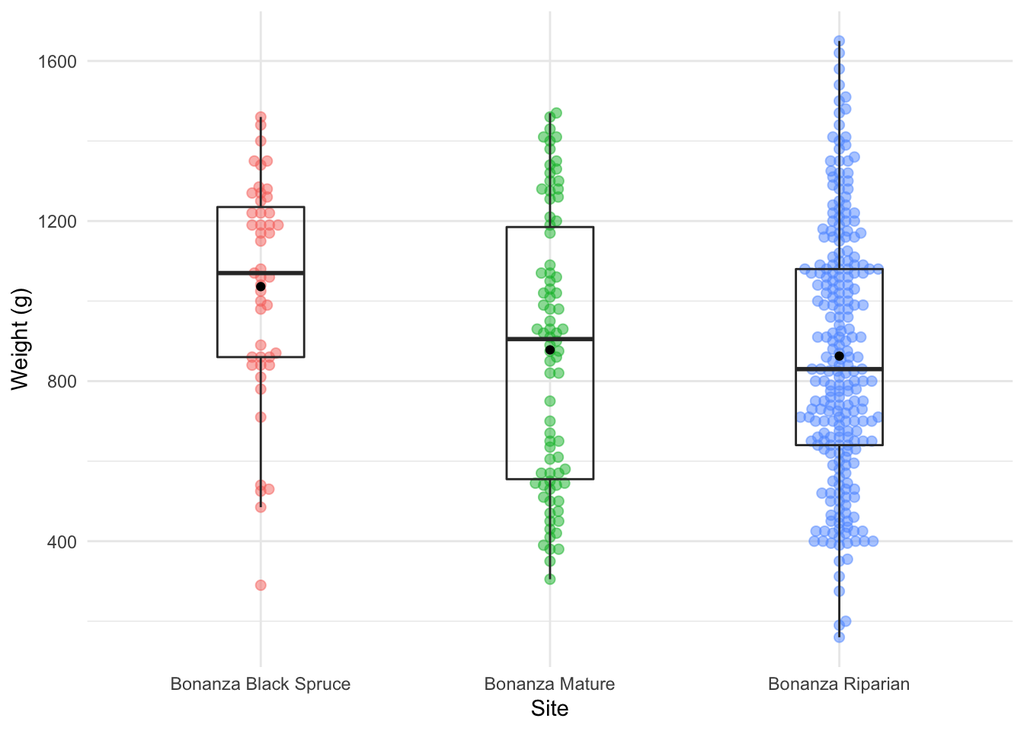

**Figure 4:** Weight observations (g) for juvenile snowshoe hares separated at three different sites in Tanana Valley, Alaska. Pink (Bonanza Black Spruce), green (Bonanza Mature), and blue (Bonanza Riparian) points indicate individual observations for weight (grams) of juvenile hares that were trapped between 1999 and 2012. Box endpoints indicate the 25<sup>th</sup> and 75<sup>th</sup> percentile values. The median value is indicated by a black line and the mean value is indicated by a black dot within the boxplot. Data: Kielland et al. (2017).

### 3) Juvenile weight comparison (male & female snowshoe hares)

**Table 1:** Descriptive statistics (mean, standard deviation, and sample size) of juvenile hares captured between 1999 and 2012. Data: Kielland et al. (2017).

| Sex | Mean weight (g) | Standard deviation (g) | Sample size |
| --- | --- | --- | --- |
| Female | 855.39 | 292.25 | 200 |
| Male | 945.86 | 333.22 | 163 |
| NA | 614.55 | 357.59 | 15 |

### 4) Relationship between juvenile weight & hind foot length

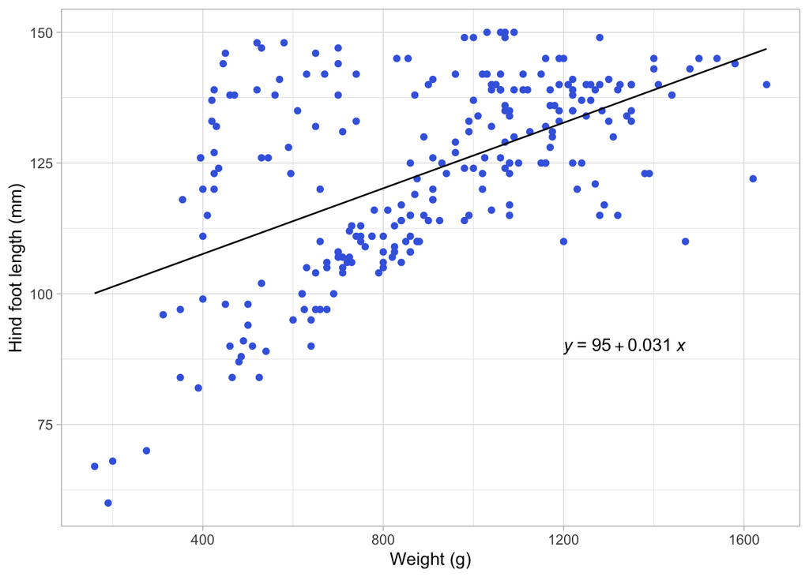

## Summary

Findings revealed through exploratory data analysis:

- Number of juvenile snowshoe hares trapped was greatest during the first two years of the study (1999 and 2000). Trap counts fluctuated throughout the remaining years, with higher counts recorded roughly every three years.
- Initial data visualization revealed that male juvenile hare weights were higher on average than female weights. The weights of juvenile hares caught at the Bonanza Black Spruce site were higher on average than individuals trapped at Bonanza Mature and Bonanza Riparian.
- The difference in means of male and female juvenile hare weights is significant, although the effect size is small.
- There is a moderate positive linear correlation between juvenile hare weight (g) and hind foot length (mm), although outliers present suggest a slight concern in the validity of this model.

Potential next steps:

- Explore correlation between vegetation density of sites and hare weight. Why does the Bonanza Black Spruce site have higher average juvenile snowshoe hare weights? Perhaps this site offers more protection from predators than others.
- Explore potential models that might fit the weight versus foot length data more accurately.
- Explore relationship between juvenile hare weight and ear length.
- Explore data for adult snowshoe hares.

## Citations

[Kielland, K., F.S. Chapin, R.W. Ruess, and Bonanza Creek LTER. 2017. Snowshoe hare physical data in Bonanza Creek Experimental Forest: 1999-Present ver 22. Environmental Data Initiative.](https://doi.org/10.6073/pasta/03dce4856d79b91557d8e6ce2cbcdc14)